# Reproducible Research Course Project 1

Amine MOUAFI

# Introduction

It is now possible to collect a large amount of data about personal movement using activity monitoring devices such as a Fitbit, Nike Fuelband, or Jawbone Up. These type of devices are part of the “quantified self” movement - a group of enthusiasts who take measurements about themselves regularly to improve their health, to find patterns in their behavior, or because they are tech geeks. But these data remain under-utilized both because the raw data are hard to obtain and there is a lack of statistical methods and software for processing and interpreting the data.

This assignment makes use of data from a personal activity monitoring device. This device collects data at 5 minute intervals through out the day. The data consists of two months of data from an anonymous individual collected during the months of October and November, 2012 and include the number of steps taken in 5 minute intervals each day.

# Loading the Data

Code to download and read the data into R

```r
temp <- tempfile()
download.file("https://d396qusza40orc.cloudfront.net/repdata%2Fdata%2Factivity.zip",temp)
file <- unzip(temp)
unlink(temp)

data <- read.csv(file, header = TRUE, sep = ',', colClasses = c("numeric", "character","integer"))
```

# Process the Data

Change date format using lubridate

```r
library(lubridate)
data$date <- ymd(data$date)
```

# Analyze the Data

**What is the mean total number of steps taken per day?**

1. Calculate the total number of steps taken per day

```r
totalsteps1 <- tapply(data$steps,data$date,sum,na.rm=TRUE)
```

2. Make a histogram of the total number of steps taken each day

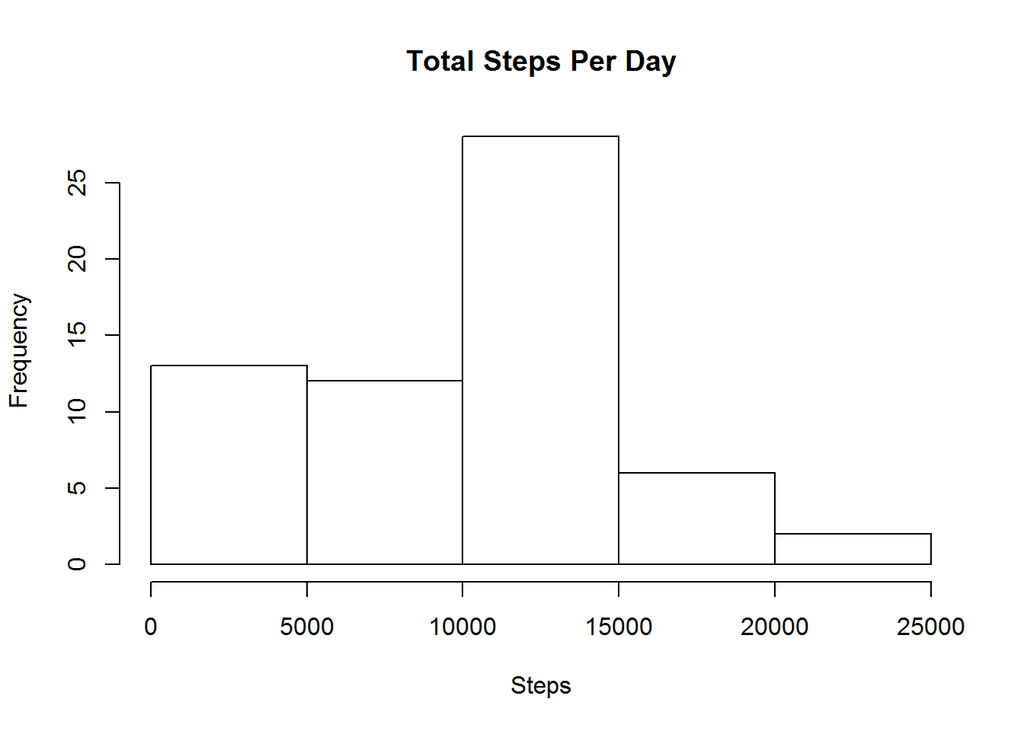

```r
hist(totalsteps1, xlab="Steps", main="Total Steps Per Day" )
```

3. Calculate and report the mean and median of the total number of steps taken per day

```r
mean(totalsteps1)
```

```
## [1] 9354.23
```

```r
median(totalsteps1)
```

```
## [1] 10395
```

**What is the average daily activity pattern?**

1. Make a time series plot

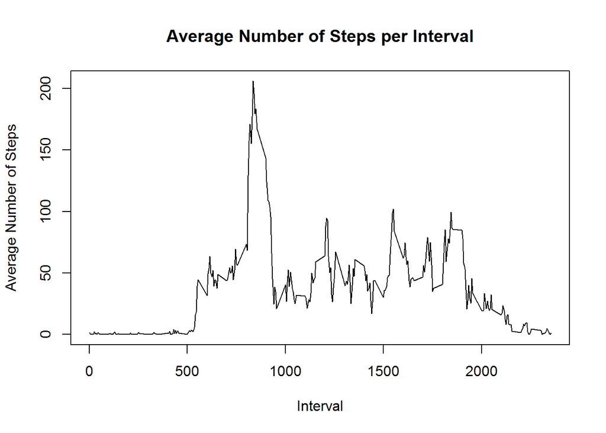

```r
##Find average steps per interval
avgperinterval <- tapply(data$steps,data$interval,mean,na.rm=TRUE)

##Create line plot
plot(row.names(avgperinterval), avgperinterval, type="l", xlab="Interval", ylab="Average Number of Steps", main="Average Number of Steps per Interval")
```

**Which 5-minute interval, on average across all the days in the dataset, contains the maximum number of steps?**

```r
which.max(avgperinterval)
```

```
## 835
## 104
```

Interval 835 at row 104

**Imputing Missing Values**

1. Calculate and report the total number of missing values in the dataset

```r
nrow(data[is.na(data),])
```

```
## [1] 2304
```

2. Devise a strategy for filling in all of the missing values in the dataset.

```r
## na data
nadata <- data[is.na(data),]

## complete data
cleandata <- data[complete.cases(data),]
## replace nas with average per interval
nadata$steps <- as.numeric(avgperinterval)
```

3. Create a new dataset that is equal to the original dataset but with the missing data filled in.

```r
##combine datasets
newdata <- rbind(nadata, cleandata)
newdata <- newdata[order(newdata[,2],newdata[,3]),]
```

4. Make a histogram of the total number of steps taken each day and Calculate and report the mean and median total number of steps taken per day. The values are different. Imputing missing data shifted the average and median of the data.

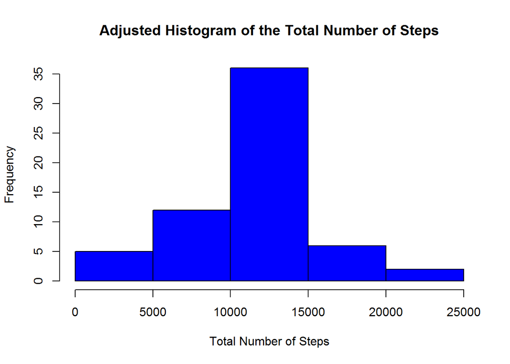

```r
##new total steps by day
newtotal <- tapply(newdata$steps,newdata$date,sum)
hist(
        newtotal,
        col = "blue",
        main = "Adjusted Histogram of the Total Number of Steps",
        xlab = "Total Number of Steps",
        breaks = 5
)
```

Calculate mean and median

```r
mean(newtotal)
```

```
## [1] 10766.19
```

```r
median(newtotal)
```

```
## [1] 10766.19
```

**Are there differences in activity patterns between weekdays and weekends?**

```r
##create new variable for weektype
library(dplyr)
newdata<- newdata %>%
        mutate(weektype= ifelse(weekdays(newdata$date)=="Saturday" | weekdays(newdata$date)=="Sunday", "Weekend", "Weekday"))
```

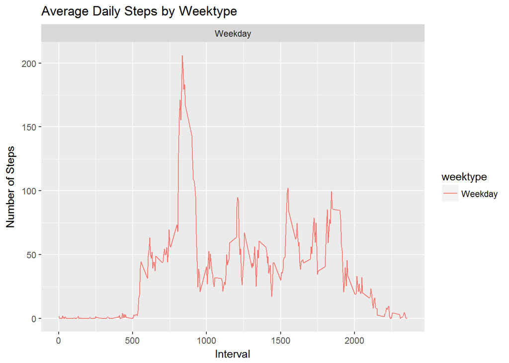

```r
##create new variable for weektype
library(ggplot2)
Interval<- newdata %>%
        group_by(interval, weektype)%>%
        summarise(avg= mean(steps, na.rm=TRUE))

plot<- ggplot(Interval, aes(x =interval , y=avg, color=weektype)) +
       geom_line() +
       labs(title = "Average Daily Steps by Weektype", x = "Interval", y = "Number of Steps") +
       facet_wrap(~weektype, ncol = 1, nrow=2)
print(plot)
```